# Chapter 4

The analysis and results of week 4 are presented below.

```r
library(MASS)
data(Boston)
#View(Boston)
```

The data set contains information of 506 areas in Boston including the median value of houses and 13 other variables, such as the crime rate, amount of air pollution, distance to employment centres and pupil-to-teacher ratio.

```r
summary(Boston)
```

```
##       crim                zn             indus            chas
##  Min.   : 0.00632   Min.   :  0.00   Min.   : 0.46   Min.   :0.00000
##  1st Qu.: 0.08205   1st Qu.:  0.00   1st Qu.: 5.19   1st Qu.:0.00000
##  Median : 0.25651   Median :  0.00   Median : 9.69   Median :0.00000
##  Mean   : 3.61352   Mean   : 11.36   Mean   :11.14   Mean   :0.06917
##  3rd Qu.: 3.67708   3rd Qu.: 12.50   3rd Qu.:18.10   3rd Qu.:0.00000
##  Max.   :88.97620   Max.   :100.00   Max.   :27.74   Max.   :1.00000
##       nox               rm             age              dis
##  Min.   :0.3850   Min.   :3.561   Min.   :  2.90   Min.   : 1.130
##  1st Qu.:0.4490   1st Qu.:5.886   1st Qu.: 45.02   1st Qu.: 2.100
##  Median :0.5380   Median :6.208   Median : 77.50   Median : 3.207
##  Mean   :0.5547   Mean   :6.285   Mean   : 68.57   Mean   : 3.795
##  3rd Qu.:0.6240   3rd Qu.:6.623   3rd Qu.: 94.08   3rd Qu.: 5.188
##  Max.   :0.8710   Max.   :8.780   Max.   :100.00   Max.   :12.127
##       rad              tax           ptratio          black
##  Min.   : 1.000   Min.   :187.0   Min.   :12.60   Min.   :  0.32
##  1st Qu.: 4.000   1st Qu.:279.0   1st Qu.:17.40   1st Qu.:375.38
##  Median : 5.000   Median :330.0   Median :19.05   Median :391.44
##  Mean   : 9.549   Mean   :408.2   Mean   :18.46   Mean   :356.67
##  3rd Qu.:24.000   3rd Qu.:666.0   3rd Qu.:20.20   3rd Qu.:396.23
##  Max.   :24.000   Max.   :711.0   Max.   :22.00   Max.   :396.90
##      lstat            medv
##  Min.   : 1.73   Min.   : 5.00
##  1st Qu.: 6.95   1st Qu.:17.02
##  Median :11.36   Median :21.20
##  Mean   :12.65   Mean   :22.53
##  3rd Qu.:16.95   3rd Qu.:25.00
##  Max.   :37.97   Max.   :50.00
```

```r
cor(Boston)
```

```
##                crim          zn       indus         chas         nox
## crim     1.00000000 -0.20046922  0.40658341 -0.055891582  0.42097171
## zn      -0.20046922  1.00000000 -0.53382819 -0.042696719 -0.51660371
## indus    0.40658341 -0.53382819  1.00000000  0.062938027  0.76365145
## chas    -0.05589158 -0.04269672  0.06293803  1.000000000  0.09120281
## nox      0.42097171 -0.51660371  0.76365145  0.091202807  1.00000000
## rm      -0.21924670  0.31199059 -0.39167585  0.091251225 -0.30218819
## age      0.35273425 -0.56953734  0.64477851  0.086517774  0.73147010
## dis     -0.37967009  0.66440822 -0.70802699 -0.099175780 -0.76923011
## rad      0.62550515 -0.31194783  0.59512927 -0.007368241  0.61144056
## tax      0.58276431 -0.31456332  0.72076018 -0.035586518  0.66802320
## ptratio  0.28994558 -0.39167855  0.38324756 -0.121515174  0.18893268
## black   -0.38506394  0.17552032 -0.35697654  0.048788485 -0.38005064
## lstat    0.45562148 -0.41299457  0.60379972 -0.053929298  0.59087892
## medv    -0.38830461  0.36044534 -0.48372516  0.175260177 -0.42732077
##                  rm         age         dis          rad         tax    ptratio
## crim    -0.21924670  0.35273425 -0.37967009  0.625505145  0.58276431  0.2899456
## zn       0.31199059 -0.56953734  0.66440822 -0.311947826 -0.31456332 -0.3916785
## indus   -0.39167585  0.64477851 -0.70802699  0.595129275  0.72076018  0.3832476
## chas     0.09125123  0.08651777 -0.09917578 -0.007368241 -0.03558652 -0.1215152
## nox     -0.30218819  0.73147010 -0.76923011  0.611440563  0.66802320  0.1889327
## rm       1.00000000 -0.24026493  0.20524621 -0.209846668 -0.29204783 -0.3555015
## age     -0.24026493  1.00000000 -0.74788054  0.456022452  0.50645559  0.2615150
## dis      0.20524621 -0.74788054  1.00000000 -0.494587930 -0.53443158 -0.2324705
## rad     -0.20984667  0.45602245 -0.49458793  1.000000000  0.91022819  0.4647412
## tax     -0.29204783  0.50645559 -0.53443158  0.910228189  1.00000000  0.4608530
## ptratio -0.35550149  0.26151501 -0.23247054  0.464741179  0.46085304  1.0000000
## black    0.12806864 -0.27353398  0.29151167 -0.444412816 -0.44180801 -0.1773833
## lstat   -0.61380827  0.60233853 -0.49699583  0.488676335  0.54399341  0.3740443
## medv     0.69535995 -0.37695457  0.24992873 -0.381626231 -0.46853593 -0.5077867
##               black      lstat       medv
## crim    -0.38506394  0.4556215 -0.3883046
## zn       0.17552032 -0.4129946  0.3604453
## indus   -0.35697654  0.6037997 -0.4837252
## chas     0.04878848 -0.0539293  0.1752602
## nox     -0.38005064  0.5908789 -0.4273208
## rm       0.12806864 -0.6138083  0.6953599
## age     -0.27353398  0.6023385 -0.3769546
## dis      0.29151167 -0.4969958  0.2499287
## rad     -0.44441282  0.4886763 -0.3816262
## tax     -0.44180801  0.5439934 -0.4685359
## ptratio -0.17738330  0.3740443 -0.5077867
## black    1.00000000 -0.3660869  0.3334608
## lstat   -0.36608690  1.0000000 -0.7376627
## medv     0.33346082 -0.7376627  1.0000000
```

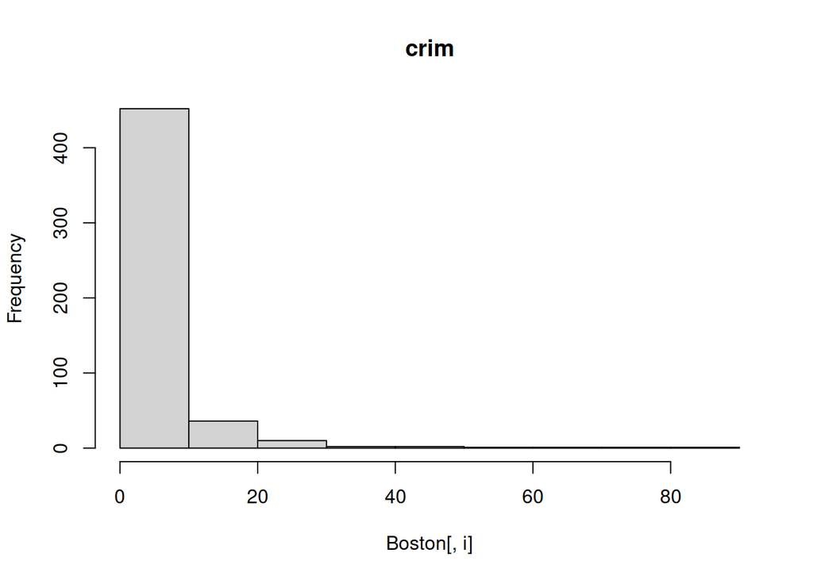

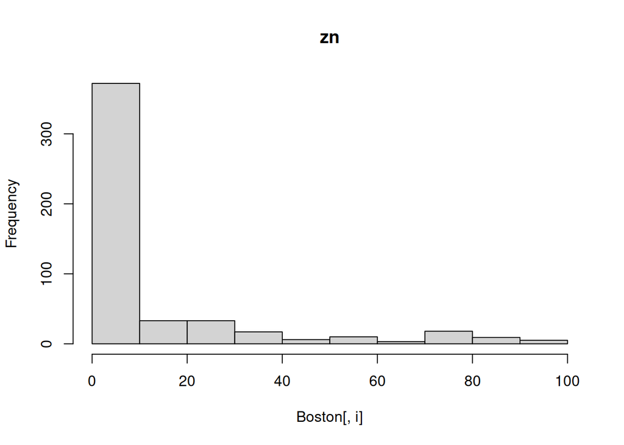

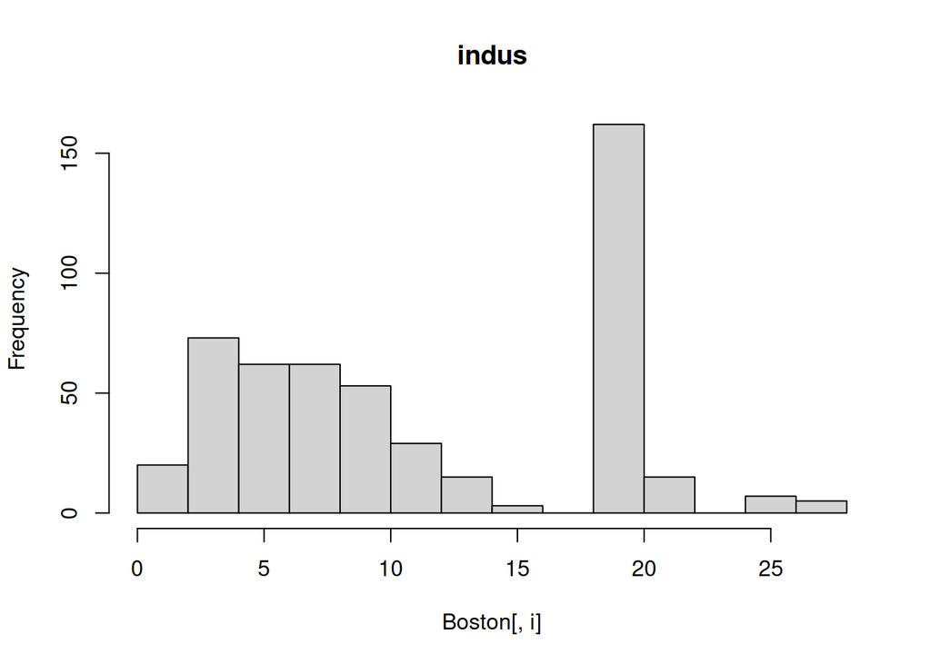

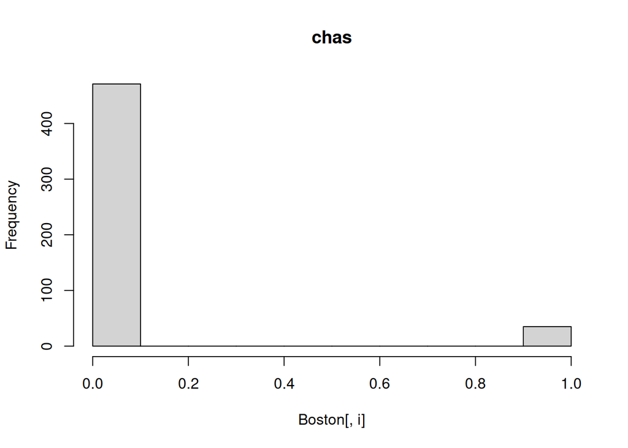

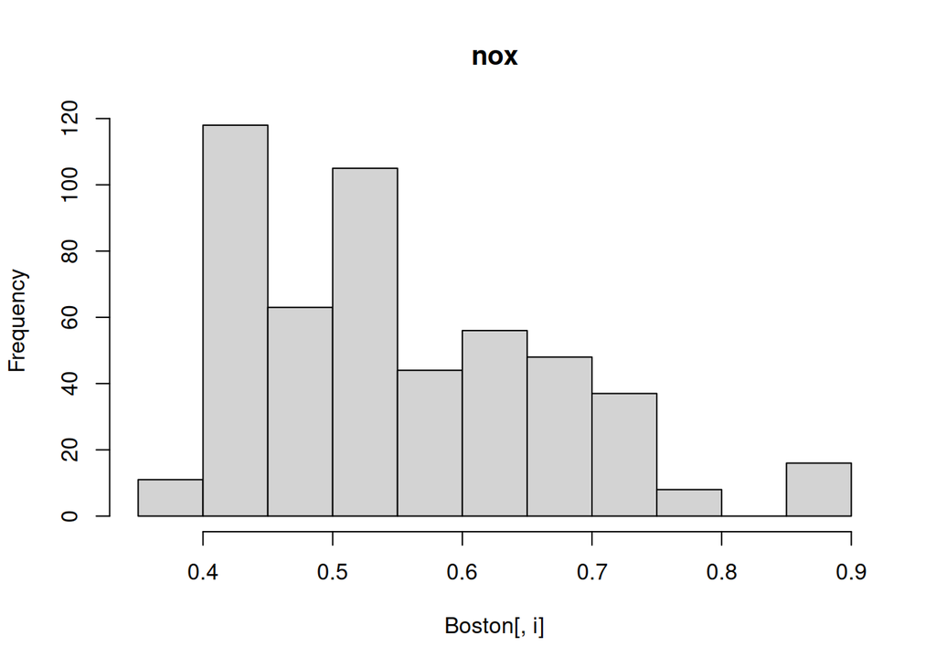

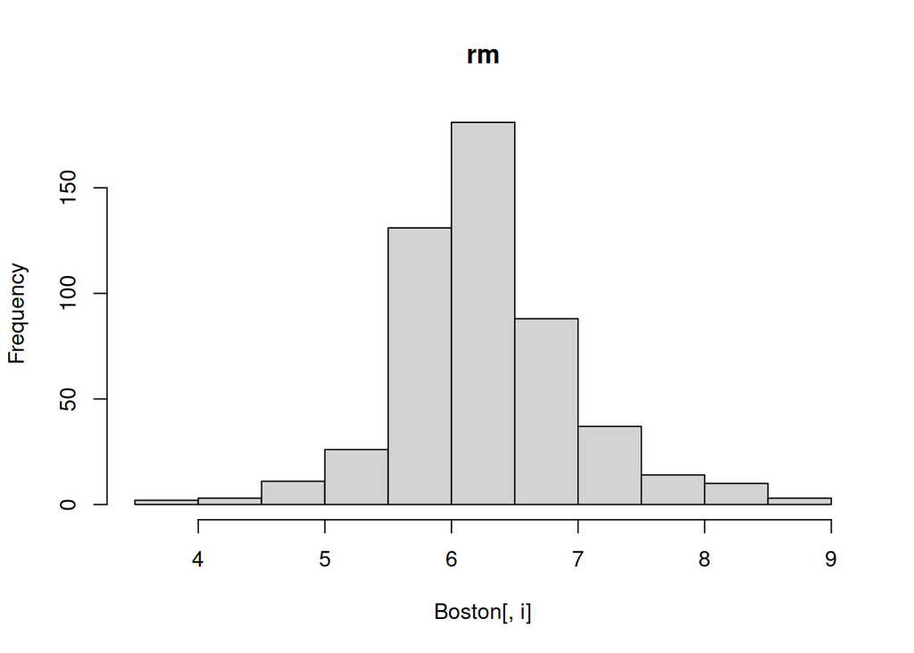

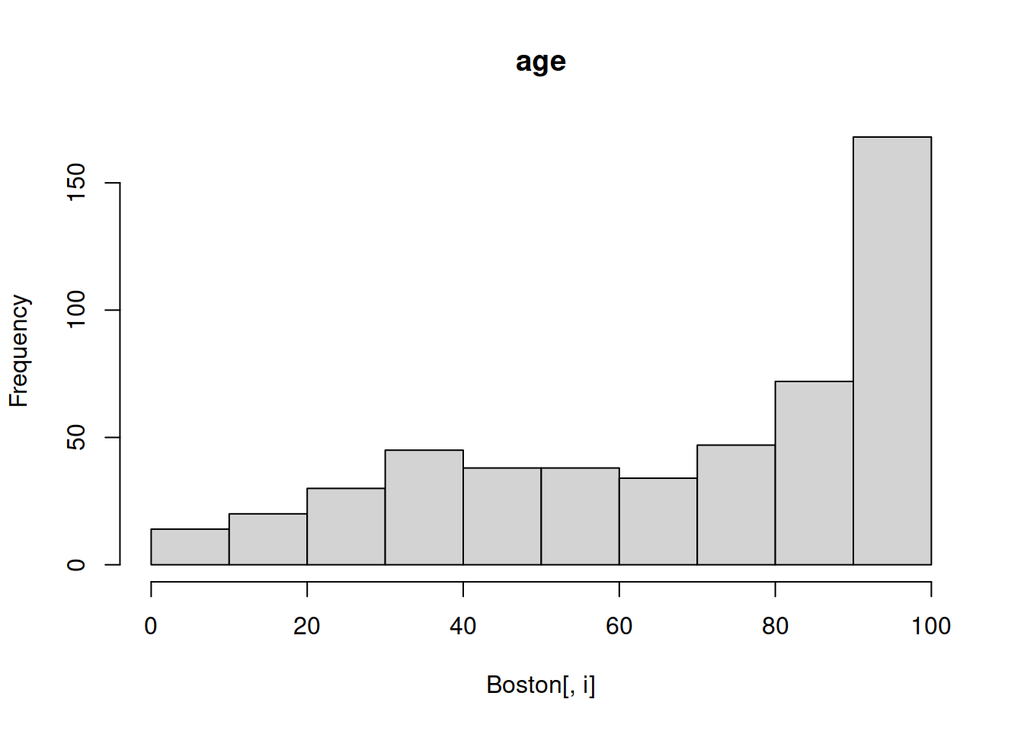

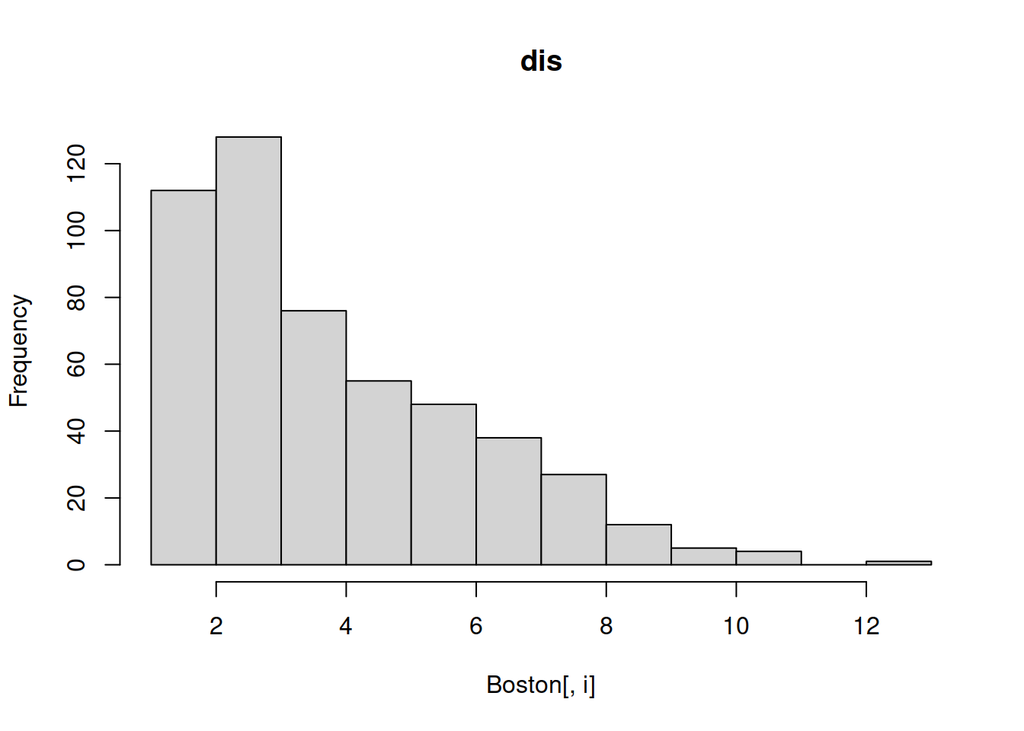

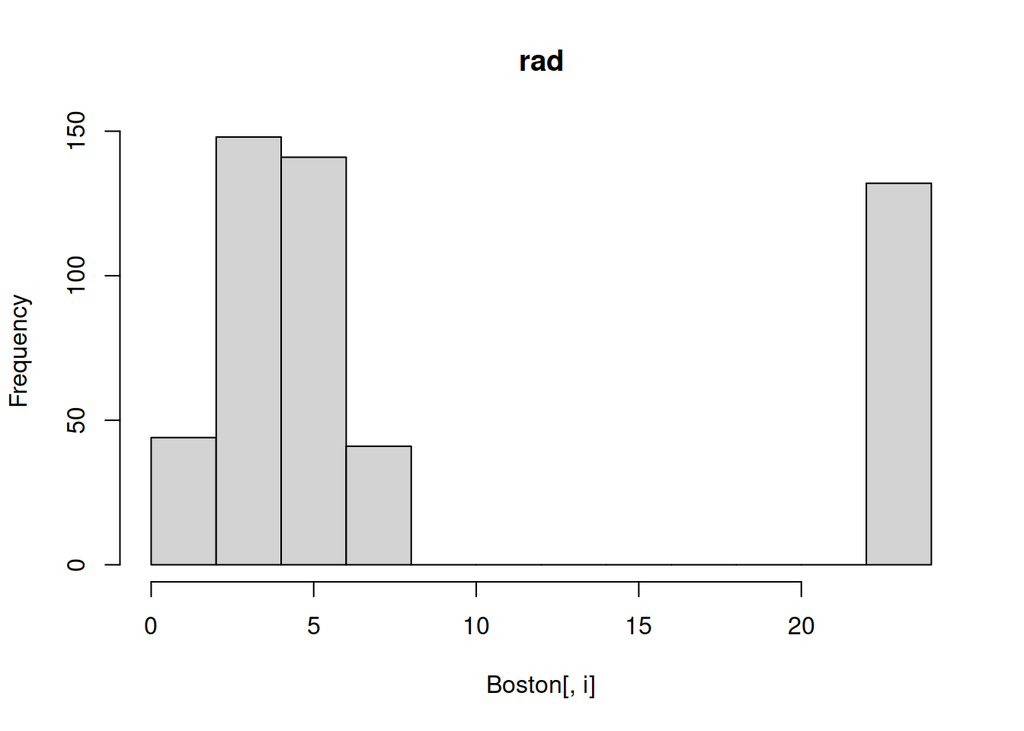

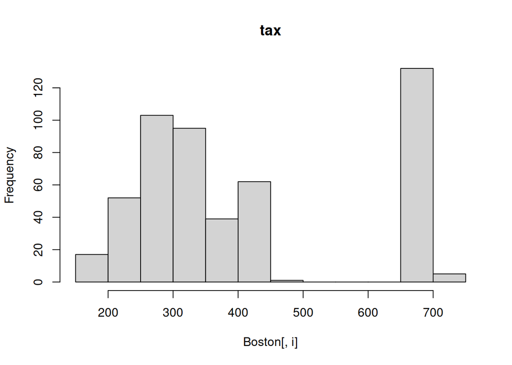

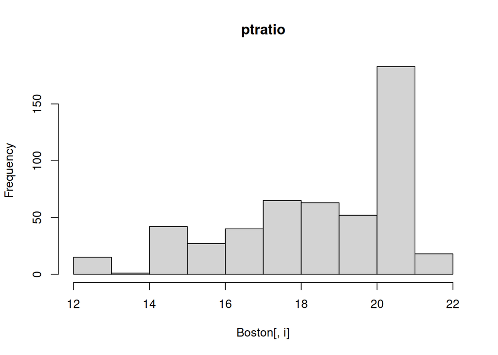

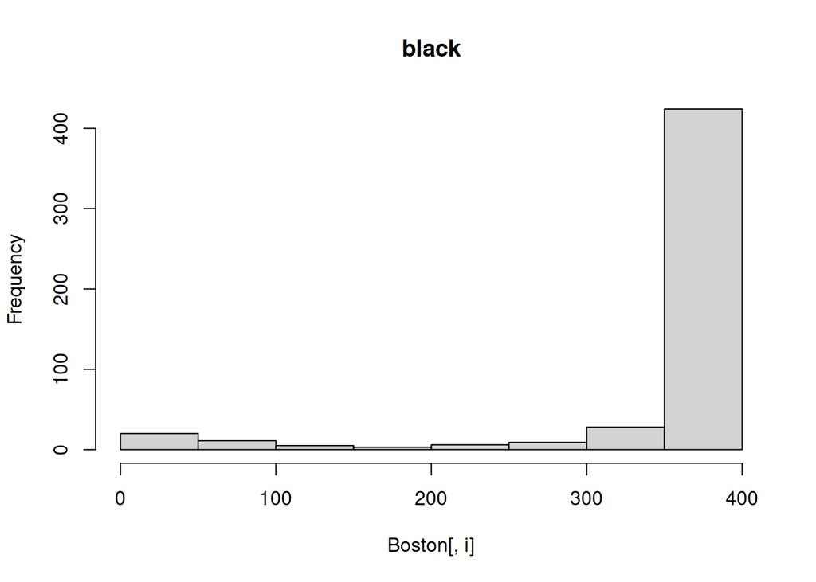

[2 more figures not shown]

```r
for(i in 1:14){
  hist(Boston[,i], main=colnames(Boston)[i])
}
```

Unsurprisingly, many of the variables describing the areas have strong correlations with each other. For example the amount of air pollution (nox) and the amount of industry (indus) have a strong positive correlation with each other and strong negative correlation with the distance to employment centres (dis). Property tax rate has a strong positive correlation with accessibility to radial highways. Median value of homes has again unsurprisingly a negative correlation with many variables such as crime rate, amount of industry, proportion of old buildings, tax rate and pupil-to-teacher ratio and a positive correlation with average number of rooms per dwelling. Many variables such as accessibility to radial highways (rad), property tax rate per $10,000 (tax) and amount of industry (indus) seem to have a high number of extreme values and distributions are very uneven.

```r
for(i in 1:14){
  Boston[,i] = (Boston[,i]-mean(Boston[,i]))/(sd(Boston[,i]))
}
summary(Boston)
```

```
##       crim                 zn               indus              chas
##  Min.   :-0.419367   Min.   :-0.48724   Min.   :-1.5563   Min.   :-0.2723
##  1st Qu.:-0.410563   1st Qu.:-0.48724   1st Qu.:-0.8668   1st Qu.:-0.2723
##  Median :-0.390280   Median :-0.48724   Median :-0.2109   Median :-0.2723
##  Mean   : 0.000000   Mean   : 0.00000   Mean   : 0.0000   Mean   : 0.0000
##  3rd Qu.: 0.007389   3rd Qu.: 0.04872   3rd Qu.: 1.0150   3rd Qu.:-0.2723
##  Max.   : 9.924110   Max.   : 3.80047   Max.   : 2.4202   Max.   : 3.6648
##       nox                rm               age               dis
##  Min.   :-1.4644   Min.   :-3.8764   Min.   :-2.3331   Min.   :-1.2658
##  1st Qu.:-0.9121   1st Qu.:-0.5681   1st Qu.:-0.8366   1st Qu.:-0.8049
##  Median :-0.1441   Median :-0.1084   Median : 0.3171   Median :-0.2790
##  Mean   : 0.0000   Mean   : 0.0000   Mean   : 0.0000   Mean   : 0.0000
##  3rd Qu.: 0.5981   3rd Qu.: 0.4823   3rd Qu.: 0.9059   3rd Qu.: 0.6617
##  Max.   : 2.7296   Max.   : 3.5515   Max.   : 1.1164   Max.   : 3.9566
##       rad               tax             ptratio            black
##  Min.   :-0.9819   Min.   :-1.3127   Min.   :-2.7047   Min.   :-3.9033
##  1st Qu.:-0.6373   1st Qu.:-0.7668   1st Qu.:-0.4876   1st Qu.: 0.2049
##  Median :-0.5225   Median :-0.4642   Median : 0.2746   Median : 0.3808
##  Mean   : 0.0000   Mean   : 0.0000   Mean   : 0.0000   Mean   : 0.0000
##  3rd Qu.: 1.6596   3rd Qu.: 1.5294   3rd Qu.: 0.8058   3rd Qu.: 0.4332
##  Max.   : 1.6596   Max.   : 1.7964   Max.   : 1.6372   Max.   : 0.4406
##      lstat              medv
##  Min.   :-1.5296   Min.   :-1.9063
##  1st Qu.:-0.7986   1st Qu.:-0.5989
##  Median :-0.1811   Median :-0.1449
##  Mean   : 0.0000   Mean   : 0.0000
##  3rd Qu.: 0.6024   3rd Qu.: 0.2683
##  Max.   : 3.5453   Max.   : 2.9865
```

```r
# Categorize crime variable
Boston$crime <- cut(Boston$crim, breaks=quantile(Boston$crim)+ c(-0.1, 0, 0, 0, 0.1), labels=c("1st","2nd","3rd", "4th"))
Boston = subset(Boston, select = -c(crim))
# Train and test split
set.seed(68)
idxs = sample(1:506)
train_idxs = idxs[1:floor(0.8*nrow(Boston))]
test_idxs = idxs[ceiling(0.8*nrow(Boston)):nrow(Boston)]
Boston_train = Boston[train_idxs,]
Boston_test = Boston[test_idxs,]
```

The data set is standardized so that each variable has zero mean and unit variance, which makes the values of different variables more comparable with each other. (Standardizing might also mean that all values are scaled between 0 and 1 but I hope that this is what was asked for..).

```r
library(ggordiplots)
model <- lda(crime~., Boston_train)
model
```

```
## Call:
## lda(crime ~ ., data = Boston_train)
##
## Prior probabilities of groups:
##       1st       2nd       3rd       4th
## 0.2450495 0.2524752 0.2524752 0.2500000
##
## Group means:
##             zn      indus        chas        nox         rm        age
## 1st  0.9541246 -0.9179094 -0.11325431 -0.8787664  0.4175470 -0.8910834
## 2nd -0.1002950 -0.3020788  0.03646311 -0.5895328 -0.1271396 -0.3749115
## 3rd -0.3846714  0.1060492  0.22945822  0.3125426  0.1141711  0.3358754
## 4th -0.4872402  1.0171306 -0.07742312  1.0401716 -0.4557229  0.8023591
##            dis        rad        tax    ptratio      black       lstat
## 1st  0.8986948 -0.6837338 -0.7429037 -0.4157047  0.3772614 -0.75752434
## 2nd  0.3803870 -0.5404996 -0.4988248 -0.1261836  0.3184573 -0.10655368
## 3rd -0.3166826 -0.3749852 -0.3128530 -0.3068701  0.1069363 -0.03630269
## 4th -0.8495458  1.6379981  1.5139626  0.7806252 -0.7317945  0.83319644
##            medv
## 1st  0.48670587
## 2nd  0.03374224
## 3rd  0.18703005
## 4th -0.63215490
##
## Coefficients of linear discriminants:
##                   LD1         LD2         LD3
## zn       0.1039744838  0.84004371 -0.83888709
## indus    0.0179511066 -0.39656444  0.44146240
## chas    -0.0750134144 -0.05114308  0.08258993
## nox      0.3921905425 -0.58047867 -1.52220582
## rm      -0.0822532395 -0.09723577 -0.13371454
## age      0.2700962412 -0.24181903 -0.23508224
## dis     -0.0865315391 -0.23737894  0.13493175
## rad      2.9674925392  0.71749458  0.14158831
## tax      0.0005257643  0.16931766  0.40058481
## ptratio  0.1231025753  0.12306259 -0.31398652
## black   -0.1147154091 -0.01134012  0.10071234
## lstat    0.1670066563 -0.16002943  0.56454777
## medv     0.1444735530 -0.31543525 -0.08302376
##
## Proportion of trace:
##    LD1    LD2    LD3
## 0.9457 0.0391 0.0152
```

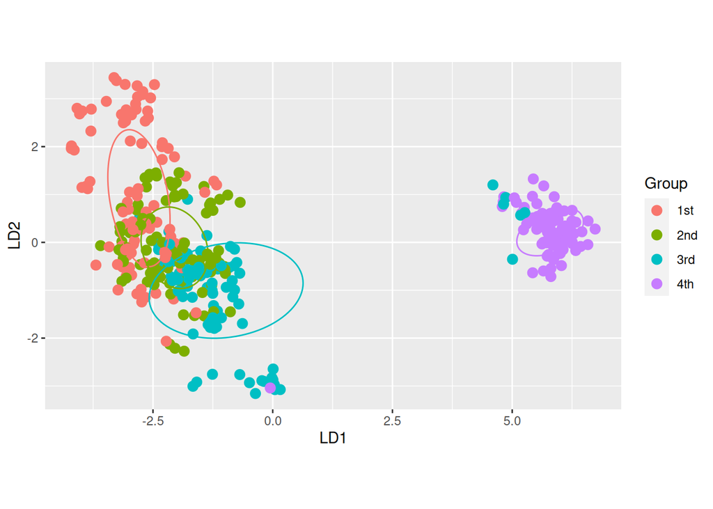

```r
gg_ordiplot(model, Boston_train$crime)
```

Seems that in the training data the model can separate the highest category from three lower ones, which get more mixed with each other.

```r
test_labels = Boston_test$crime
Boston_test = subset(Boston_test, select = -c(crime))
pred = predict(model, Boston_test)$class
table(Predicted = pred, Actual = test_labels)
```

```
##          Actual
## Predicted 1st 2nd 3rd 4th
##       1st  17   3   0   0
##       2nd  10  12   4   0
##       3rd   1   9  20   0
##       4th   0   0   0  26
```

The test results seem to follow the results of the biplot from training data. The hihgest category (4) is perfectly classified. Classes 3 and 1 get a little bit more mixed with class 2, and even half of all observations belonging to class 2 are incorrectly classified as either class 1 or 3. However, the results seem fairly good given that the categorization boundaries were quite arbitrary (the distribution of original response variable crime may not support the categorization into four even categories). The model seems to handle the order of the categories pretty well, since only one observation belonging to class 1 is classified more than one class away from the correct one.

I am a little bit confused what following problem statement means since I think this is what we exactly did in part 4: “Reload the Boston dataset and standardize the dataset (we did not do this in the Exercise Set, but you should scale the variables to get comparable distances).” However, here we go:

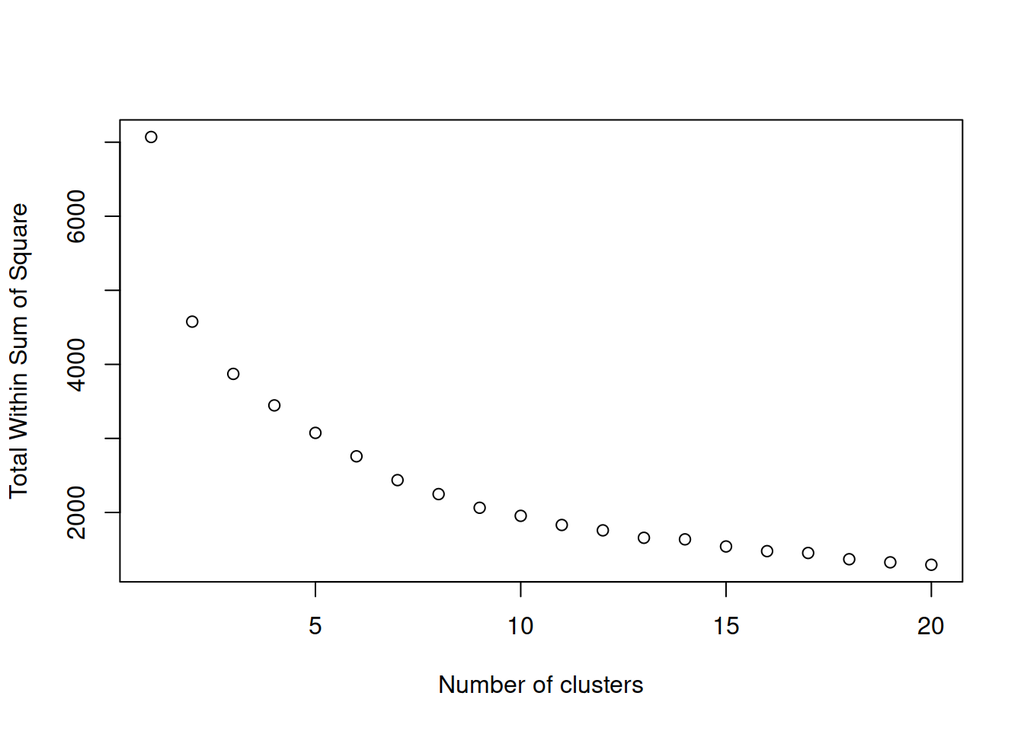

```r
data(Boston)
for(i in 1:14){
  Boston[,i] = (Boston[,i]-mean(Boston[,i]))/(sd(Boston[,i]))
}
# run clustering algorithm for 1-10 clusters and save the total sum of squares within cluster
ss = c()
for(k in 1:20){
  km = kmeans(Boston, centers = k, nstart = 25)
  ss = c(ss, km$tot.withinss)
}

plot(1:20, ss, main ="", ylab="Total Within Sum of Square", xlab="Number of clusters")
```

The smaller the sum of squares within the clusters indicates that the observations within the cluster are closer to each other and thus that the clustering is better. However, the TWSS will always get lower, when the number of clusters is increased but it is not reasonable to assign every single observation in its own cluster. We are thus looking for a point in the plot where the slope starts to get even. In this case it could be just two clusters, since after that every new cluster that we introduce decreases the TWSS but not very notably. Also the results from the lda would support two clusters. Let’s fit a new model with k=2 clusters and visualize the results.

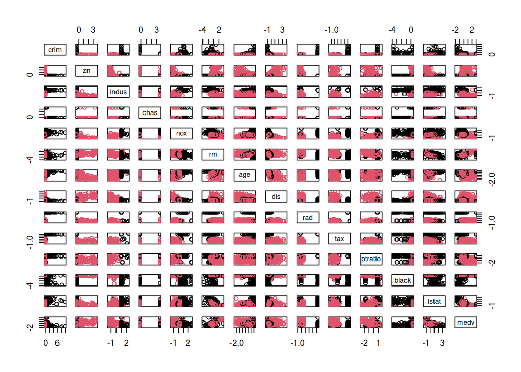

```r
k2 = kmeans(Boston, centers = 2, nstart = 25)
pairs(Boston, col=k2$cluster)
```

It seems (when we zoom in to the picture) that our two clusters are very well separable and can be even interpreted as “good” and “bad” areas. The clusters clearly differ from each other in terms of crime rate, amount of industry, air pollution, taxation and closeness to highways.

Again, I unfortunately didn’t have time for Bonus exercises.. :’(